# Install R, RStudio and packages

# Windows instructions

This section provides instructions for downloading and installing R and RStudio on a Windows machine.

**NOTE: Because of backward dependency issues, some code that we talk about in class will NOT work if you do not download the latest version of R/RStudio. Because the class is pretty large, I will NOT be able to address issues due to older versions in class.**

## Before you start

Make sure that you have about 500 MB of free space on your machine. We will need this space to install both R and RStudio, and when the program installs the compressed files expand to take much more space.

## Installing R

1. Go to [this website](https://cran.r-project.org/bin/windows/base/).
2. Click on the “Download R 4.1.1 for Windows” link at the top of the page. Your download should start.
3. Once the file has been downloaded, click on it: it will unpack and copy all the files to your hard drive. (If you run into any issues, consult the FAQ sections in the link above.)
- ACCEPT the default startup options.
- YES to a Start Menu folder, and
- YES to a desktop icon and to a Quick launch icon.

R is now **installed** on your computer.

**Note**: This version of R should run with no problems on Windows 10 or later.

### Testing R

1. Double-click on the R desktop shortcut. A window looking something like this should pop up:

[figure not shown]

The `>` character is called the prompt and is the place where we enter commands for the program to interpret. For instance, if you type `25+26` followed by the return/enter key, you will see:

```r
25+26
```

```
## [1] 51
```

2. To quit R, call the quit function by typing `q()` and htting the return key.

```r
q()
```

R will ask you if you want to save your work. Don’t save it. You have now left R.

We are not going to use R this way often, as we will use an integrated environment called RStudio.

## Installing RStudio

1. Go to [this website](https://www.rstudio.com/products/rstudio/download/#download).
2. Under the “All Installers” section, click on the “RStudio-1.4.1717.exe” link. The file download will begin.
3. Once the file has been downloaded, click on it and walk through the installation process.
- YES to the question on whether you want to allow this app to make changes to your device.
- Choose Install Location: `C:\Program Files\RStudio`.

RStudio is now **installed** on your computer.

**Note**: For RStudio to work, R needs to be installed first.

### Testing RStudio

1. Double-click on the RStudio icon in the Applications. A window titled “RStudio” should pop up, looking something like this:

[figure not shown]

2. Just as in R, the `>` character in the Console window is where we enter commands for the program to interpret.
3. To exit RStudio, click on the red X at the top-right corner of the window. If prompted to save the workspace, do not save it.

## A note about filenames in Windows

In the Windows system, path names use backslashes, e.g. `C:\Users\username\RWork\`. R, on the other hand, inherits its file and folder naming conventions from Unix which uses forward slashes instead: `C:/Users/susan/RWork/`.

In Unix conventions, backslashes are actually used for a different purpose (to isolate special characters and stop them from being immediately interpreted).

As a rule, to avoid problems, we should avoid naming directories and files with spaces and special characters.

If you already have an important directory with a space in its name, know that when trying to reference that directory in R, you have to put a backslash in front of each space.

# Mac Instructions

This section provides instructions for downloading and installing R and RStudio on an Apple Macintosh machine. (Note: I do not personally own a Mac machine so some of these instructions might be outdated. If the installation instructions you face are different from what is outlined here, please let me know.)

**NOTE: Because of backward dependency issues, some code that we talk about in class will NOT work if you do not download the latest version of R/RStudio. Because the class is pretty large, I will NOT be able to address issues due to older versions in class.**

## Before you start

1. Check which version of Mac OS you have. To do this, click on the Apple icon on the top-left of your screen, then click “About This Mac”. A little window should pop up with version information.

[figure not shown]

2. Make sure that you have about 500 MB of free space on your machine. We will need this space to install both R and RStudio, and when the program installs the compressed files expand to take much more space.

## Installing R

1. Go to [this website](https://cran.r-project.org/bin/macosx/).
2. If your mac is OS X 10.13 and higher (this should be the case for most of you), click the `R-4.1.1.pkg` link.
3. After clicking on the link, the file (package installer) will be downloaded onto your computer. Once the file has been downloaded, click on the link and walk through the installation process. Accept the default options for now.

R is now **installed** on your computer.

### Testing R

1. Double-click on the R icon in the Applications folder. A window titled “R Console” should pop up:

[figure not shown]

The `>` character is called the prompt and is the place where we enter commands for the program to interpret. For instance, if you type `25+26` followed by the return/enter key, you will see:

```r
25+26
```

```
## [1] 51
```

2. To quit R, call the quit function by typing `q()` and htting the return key.

```r
q()
```

R will ask you if you want to save your work:

[figure not shown]

Click on “Don’t Save”. You have now left R.

We are not going to use R this way often, as we will use an integrated environment called RStudio.

## Installing RStudio

1. Go to [this website](https://www.rstudio.com/products/rstudio/download/#download).
2. Under the “All Installers” section, click on the “RStudio-1.4.1717.dmg” link. The file download will begin
3. Once the file has been downloaded, click on it. A window should pop up:

[figure not shown]

Click on the RStudio icon and drag it into the Applications folder.

RStudio is now **installed** on your computer.

**Note**: For RStudio to work, R needs to be installed first.

### Testing RStudio

1. Double-click on the RStudio icon in the Applications. A window titled “RStudio” should pop up, looking something like this:

[figure not shown]

2. Just as in R, the `>` character in the Console window is where we enter commands for the program to interpret.
3. To exit RStudio, click “RStudio” in the menu bar, then click “Quit RStudio”. Alternatively, use the `Cmd-Q` shortcut. If prompted to save the workspace, do not save it.

# Installing packages

This section describes how to install the packages needed for STATS 32, as well as how to check that the R markdown system is working fine on your machine. (We will learn more about what packages are later in the course.)

If the name of a package is `pkgName`, the command to install it is as follows:

```r
install.packages("pkgName")
```

Type the command above into the console in RStudio and press Enter. (**Note:** You must put quotation marks around `pkgName`!) You should see a message showing the progress of the download.

To check that the package has been downloaded and installed correctly, type the following into the console:

```r
library(pkgName)
```

If the package has been correctly installed, you will not see an error message. Some notes about installation:

- A common error message is `Error in library(xxx) : there is no package called ‘xxx’` (where `xxx` is the name of the package). This means that the package was not installed properly.
- Some packages will print some information to the screen. Just because it is in red font does not mean that it is an error message. An error message will usually have the word “error” somewhere in there. If in doubt, check with me.

Install the following list of packages; we will be using them at various parts of the course.

- `forcats`
- `fueleconomy`
- `knitr`
- `lubridate`
- `maps`
- `nycflights13`
- `tidyverse`

## Testing the R markdown system

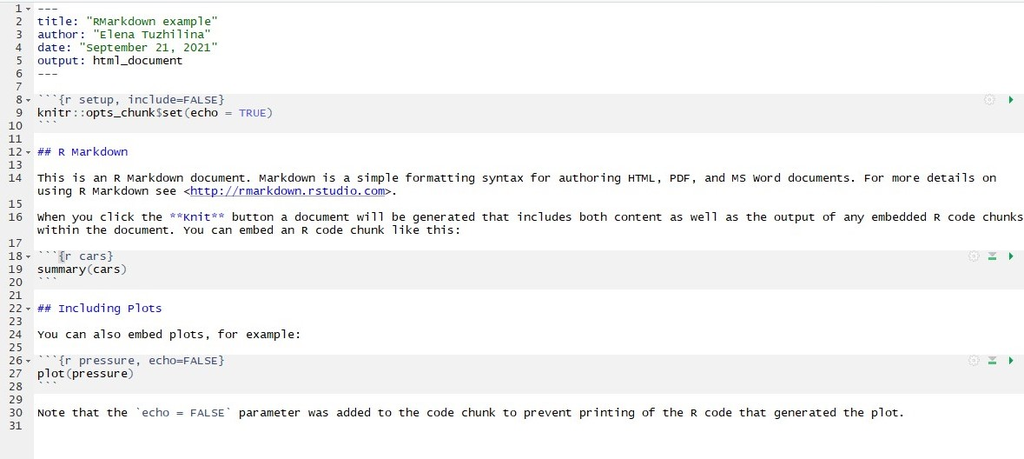

After some time, a preview of the document should open up in a new window, looking like this:

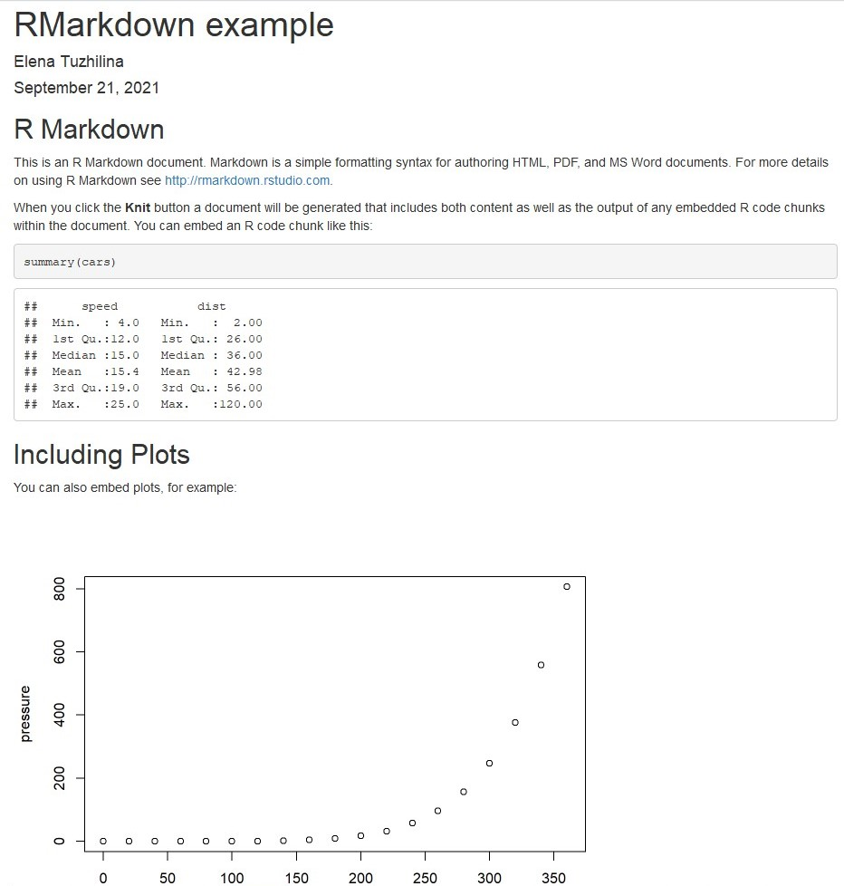

If you followed along and everything went fine, great! You are ready to go. **If you ran into any issues along the way, please make a post on Campuswire and attach the error message, along with a description of what happened, your R & RStudio versions, and your operating system. That will help me to figure out what might have gone wrong.**